# Using rcox-package

Tuomas Rajala

2017-10-11

This doc gives a short example of how to simulate shot-noise and product-noise Cox patterns.

We will use `spatstat` to simulate the generator pattern and for some other tools, so load it as well.

```r
library(rcox)
library(spatstat)
```

# Simulation

The first step is to generate the generator pattern. Let’s create two of them for two different outcomes:

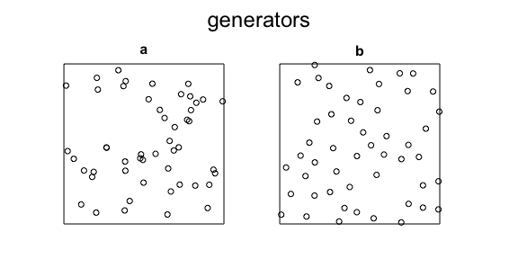

```r
set.seed(1)
x1 <- runifpoint(50)
x2 <- rMaternII(120, 0.08)
generators <- listof(a=x1, b=x2)
plot(generators)
```

## The basic idea

Given a generator pattern ${\mathbf{x}}$, sample a pattern $\mathbf{y}$ from $Poisson( F(.;{\mathbf{x}}))$, where the intensity $F$ is given by one of the two ways:

1. `sum`-type: For $u\in W$ where $W$ is the window,
   $$F(u; {\mathbf{x}}) = \alpha \sum_{x\in{\mathbf{x}}} k_\sigma(u-x)$$
   where $\alpha>0$ adjusts for intensity and $k_\sigma$ is a kernel (prob. density in 2D) with parameter $\sigma$. This is called *shot-noise*-field. Some details of this model:
   - $\lambda_y=\lambda_x\alpha$
   - $g_y(r) = (k_\sigma*g_x)(r) + (k_\sigma*k_\sigma)(r)/\lambda$ ($*$ means convolution)
2. `product`-type: For $u\in W$
   $$F(u;{\mathbf{x}}) = e^{\alpha_1}\prod_{x\in {\mathbf{x}}}[1 + \alpha_2 k_\sigma(u-x)/k_\sigma(0)]$$
   where $\alpha_1$ again adjusts the intensity and $\alpha_2\in[-1,\infty)$ is an interaction parameter. This is called *product*-shot-noise, following Jalilian et al. 2015. Some details:
   - $\lambda_y = \exp\left[\alpha + \beta\lambda_x/k_\sigma(0)\right]$
   - $g_y(r) = \exp\left[\lambda_x\alpha_2^2 (k_\sigma*k_\sigma)(r)/k_\sigma(0)^2\right]$

## Setting up the model

We set up the models like this:

```r
lam1 <- lambda(x1, kernel = "gauss", sigma = 0.05, alpha = 3, type = "sum")
lam2 <- lambda(x2, kernel = "step", sigma = 0.1, alpha = c(log(100), -0.5), type = "prod")
```

The documentation lists the options.

## Checking the field

We can “evaluate” the $F$ on a grid to see how the surface looks like.

```r
field1 <- coxintensity2matrix(lam1, W = square(1))
field2 <- coxintensity2matrix(lam2, bbox = cbind(0:1, 0:1), nx = 128)
```

Note how the bounding box can be given in two ways.

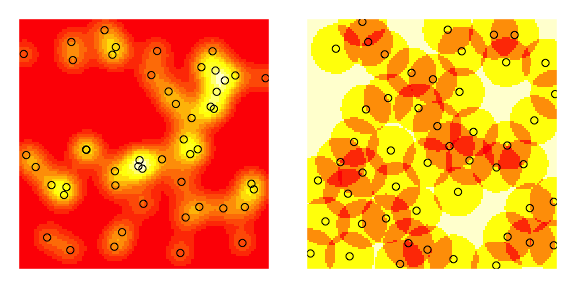

```r
par(mfrow=c(1,2), mar=c(1,1,1,1))
plot(field1, axes =F)
points(x1)
plot(field2, axes =F, scale=log)
points(x2)
```

Red means low intensity (not preferred), white means high intensity (preferred).

## Simulating

The simulation uses either a thinning approach (free point count) or Metropolis-Hastings (fixed point count). The calls:

```r
s1 <- rcox(lambda = lam1, bbox = cbind(0:1, 0:1))
s2 <- rcox(lambda = lam2, n = 100, bbox = cbind(0:1, 0:1), iter = 1e4, verb=T)
# turn to ppp-objects
y1 <- cox2ppp(s1)
y2 <- cox2ppp(s2)
```

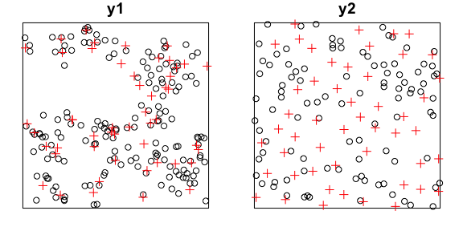

```r
par(mfrow=c(1,2), mar=c(1,1,1,1))
plot(y1)
points(x1, pch=3, col = 2)
plot(y2)
points(x2, pch=3, col = 2)
```

There we have it.

*EOF*